# Association Rules project

Ronny Meza

Ocober 2018

[output not shown]

Lybraries

```r
library(xlsx)
library(arules)
```

```r
library (arulesViz)
library(datasets)
library(rje)
library(plyr)
library(colorspace)
options(warn=-1)
```

** Introduction **

In these project will be illustrated how to use Arules for analyze a dataset has 1 month (30 days), of real points of sale from a typical grocery store. The dataset contain 9835 transactions and the elements are in 169 categories. In the present blog, it will aboard, different algorithm from the library Arules, with the goal to examine the data and to extract the consume trend rules and the associations between a group of products and other, out of what might be obvious to the owner of the grocery store.

```r
# Input data
groceries <- read.transactions("groceries.csv", sep = ",")
```

** Data Analizes **

```r
dim(groceries)  # 9835 169
```

```
## [1] 9835  169
```

```r
summary(groceries)
```

```
## transactions as itemMatrix in sparse format with
##  9835 rows (elements/itemsets/transactions) and
##  169 columns (items) and a density of 0.02609146
##
## most frequent items:
##       whole milk other vegetables       rolls/buns             soda
##             2513             1903             1809             1715
##           yogurt          (Other)
##             1372            34055
##
## element (itemset/transaction) length distribution:
## sizes
##    1    2    3    4    5    6    7    8    9   10   11   12   13   14   15
## 2159 1643 1299 1005  855  645  545  438  350  246  182  117   78   77   55
##   16   17   18   19   20   21   22   23   24   26   27   28   29   32
##   46   29   14   14    9   11    4    6    1    1    1    1    3    1
##
##    Min. 1st Qu.  Median    Mean 3rd Qu.    Max.
##   1.000   2.000   3.000   4.409   6.000  32.000
##
## includes extended item information - examples:
##             labels
## 1 abrasive cleaner
## 2 artif. sweetener
## 3   baby cosmetics
```

```r
groceries[1:2, ]  #
```

```
## transactions in sparse format with
##  2 transactions (rows) and
##  169 items (columns)
```

It can be see that the data are in Sparse format and that the different items are organized in 169 columns, but in this point it is not know ledged a data organization schema. The summary indicated that 9835 transactions are distributed a long of 169 columns. The products with major frequency content (consume) are: the whole milk, followed by vegetables, bakery products, then are located the sodas, and the yogurts; the rest of the products are included under others category.

```r
inspect(groceries[1:11])
```

```
##      items
## [1]  {citrus fruit,
##       margarine,
##       ready soups,
##       semi-finished bread}
## [2]  {coffee,
##       tropical fruit,
##       yogurt}
## [3]  {whole milk}
## [4]  {cream cheese,
##       meat spreads,
##       pip fruit,
##       yogurt}
## [5]  {condensed milk,
##       long life bakery product,
##       other vegetables,
##       whole milk}
## [6]  {abrasive cleaner,
##       butter,
##       rice,
##       whole milk,
##       yogurt}
## [7]  {rolls/buns}
## [8]  {bottled beer,
##       liquor (appetizer),
##       other vegetables,
##       rolls/buns,
##       UHT-milk}
## [9]  {pot plants}
## [10] {cereals,
##       whole milk}
## [11] {bottled water,
##       chocolate,
##       other vegetables,
##       tropical fruit,
##       white bread}
```

Using this resource, it is possible to have a idea about data organization, note that the buy operation carry out by each individual is organized by rows; note that have not an specific order by column, each product appear in the order how it was register the buy.

** Checking the buy frequency od different items **

```r
# Itemfrequency Checking
itemFrequency(groceries[, 1:20])
```

```
## abrasive cleaner artif. sweetener   baby cosmetics        baby food
##     0.0035587189     0.0032536858     0.0006100661     0.0001016777
##             bags    baking powder bathroom cleaner             beef
##     0.0004067107     0.0176919166     0.0027452974     0.0524656838
##          berries        beverages     bottled beer    bottled water
##     0.0332486019     0.0260294865     0.0805287239     0.1105236401
##           brandy      brown bread           butter      butter milk
##     0.0041687850     0.0648703610     0.0554143366     0.0279613625
##         cake bar          candles            candy      canned beer
##     0.0132180986     0.0089476360     0.0298932384     0.0776817489
```

```r
max(itemFrequency(groceries[, 1:20]))  #Max. frequency
```

```
## [1] 0.1105236
```

Note that under this search parameter it is difficult to have an idea about which product is purchased with major frequency in the first 20 columns. When evaluating the maximum it can be observed that water bottles are acquired quite frequently, which is very logical and does not provide information that the owner of the establishment does not know. However, this knowledge could mark a start point; it should that could be interesting the products there are sold as well as water bottles.

** Evaluation of itemsets with support major than 0.1 **

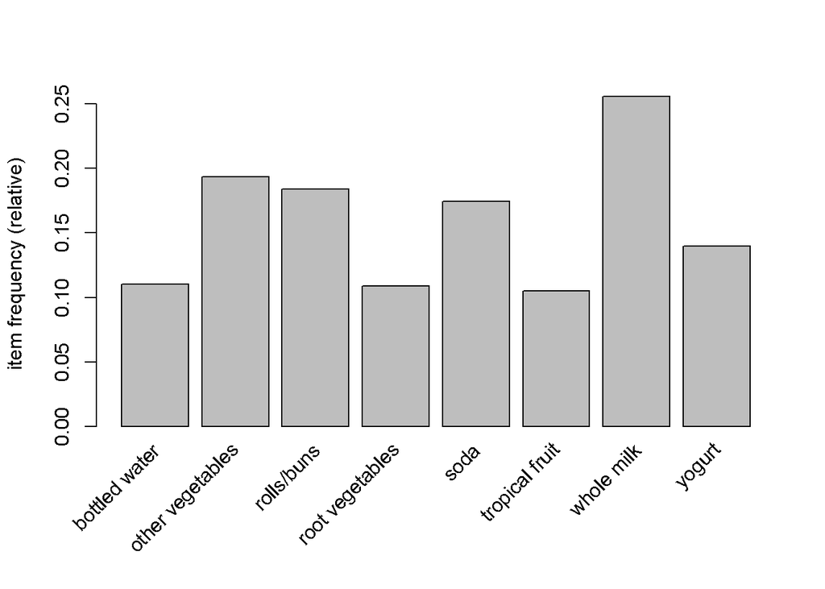

```r
itemFrequencyPlot(groceries, support = 0.1)
```

In the bar chart you can see that there are other products that are sold as well as water bottles, which appear first followed by: other vegetables, rolls and bread, tubers, soft drinks, tropical fruits, whole milk and yogurt.

** Evaluation of purchase frequency of 30 principal product **

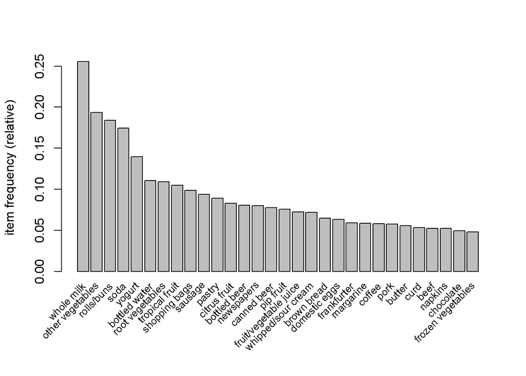

```r
itemFrequencyPlot(groceries, topN = 30, cex.names = 0.8)
```

In the graph above you can see a bar chart that indicates in an organized way the most sold products in the grocery store, which are headed by whole milk, vegetables, rolls and bread, soda, yogurt, bottles of waters, tubers, tropical fruits, among others. However, the owner of the establishment knows very well the most sold products and knows that these products must be close to each other. Therefore, this study will focus on products that have a lower purchase frequency and could provide unknown information to the owner of the establishment.

** Training a model with grocerie dataset **

```r
groceryrules <- apriori(groceries, parameter = list(support = 0.006, confidence = 0.25,
    minlen = 2))
```

```
## Apriori
##
## Parameter specification:
##  confidence minval smax arem  aval originalSupport maxtime support minlen
##        0.25    0.1    1 none FALSE            TRUE       5   0.006      2
##  maxlen target   ext
##      10  rules FALSE
##
## Algorithmic control:
##  filter tree heap memopt load sort verbose
##     0.1 TRUE TRUE  FALSE TRUE    2    TRUE
##
## Absolute minimum support count: 59
##
## set item appearances ...[0 item(s)] done [0.00s].
## set transactions ...[169 item(s), 9835 transaction(s)] done [0.00s].
## sorting and recoding items ... [109 item(s)] done [0.00s].
## creating transaction tree ... done [0.00s].
## checking subsets of size 1 2 3 4 done [0.00s].
## writing ... [463 rule(s)] done [0.00s].
## creating S4 object  ... done [0.00s].
```

** Performance evaluation of the Model **

```r
summary(groceryrules)
```

```
## set of 463 rules
##
## rule length distribution (lhs + rhs):sizes
##   2   3   4
## 150 297  16
##
##    Min. 1st Qu.  Median    Mean 3rd Qu.    Max.
##   2.000   2.000   3.000   2.711   3.000   4.000
##
## summary of quality measures:
##     support           confidence          lift            count
##  Min.   :0.006101   Min.   :0.2500   Min.   :0.9932   Min.   : 60.0
##  1st Qu.:0.007117   1st Qu.:0.2971   1st Qu.:1.6229   1st Qu.: 70.0
##  Median :0.008744   Median :0.3554   Median :1.9332   Median : 86.0
##  Mean   :0.011539   Mean   :0.3786   Mean   :2.0351   Mean   :113.5
##  3rd Qu.:0.012303   3rd Qu.:0.4495   3rd Qu.:2.3565   3rd Qu.:121.0
##  Max.   :0.074835   Max.   :0.6600   Max.   :3.9565   Max.   :736.0
##
## mining info:
##       data ntransactions support confidence
##  groceries          9835   0.006       0.25
```

The summary indicates that 463 rules were built, which can be overwhelming, so the rules organized by support will be revised.

```r
inspect(sort(groceryrules, by = "support")[1:10])
```

```
##      lhs                   rhs                support    confidence
## [1]  {other vegetables} => {whole milk}       0.07483477 0.3867578
## [2]  {whole milk}       => {other vegetables} 0.07483477 0.2928770
## [3]  {rolls/buns}       => {whole milk}       0.05663447 0.3079049
## [4]  {yogurt}           => {whole milk}       0.05602440 0.4016035
## [5]  {root vegetables}  => {whole milk}       0.04890696 0.4486940
## [6]  {root vegetables}  => {other vegetables} 0.04738180 0.4347015
## [7]  {yogurt}           => {other vegetables} 0.04341637 0.3112245
## [8]  {tropical fruit}   => {whole milk}       0.04229792 0.4031008
## [9]  {tropical fruit}   => {other vegetables} 0.03589222 0.3420543
## [10] {bottled water}    => {whole milk}       0.03436706 0.3109476
##      lift     count
## [1]  1.513634 736
## [2]  1.513634 736
## [3]  1.205032 557
## [4]  1.571735 551
## [5]  1.756031 481
## [6]  2.246605 466
## [7]  1.608457 427
## [8]  1.577595 416
## [9]  1.767790 353
## [10] 1.216940 338
```

In the table it can be seen that until now there is no new information, the vegetables, the whole milk, and the different products that appear listed in the bar graph are those that lead in order of position the table. In this sense, an interesting question would be, what do people who do not carry whole milk buy?

For this, a boolean mark true or false in the rows will be added.

```r
# Data preparation
compras <- as(groceries, "matrix")

# Removal of duplicates
dim(compras)
```

```
## [1] 9835  169
```

```r
compras <- unique(compras)
dim(compras)  #se puede observar el efecto de la remocion de los datos redundantes
```

```
## [1] 7011  169
```

```r
# Cleaning NA values
compras[is.na(compras)] <- FALSE

# Preparation of vector negation for whole milk
indice <- grep("whole milk", colnames(compras))  # columna de la leche entera
milk <- compras[, indice]
no_milk <- ifelse(milk == TRUE, FALSE, TRUE)

compras_2 <- cbind(compras, no_milk)  #Nuevo arreglo con la columna no_milk
compras_3 <- subset(compras_2, select = -c(indice))  #remocion de la columna whole milk
```

Once the new data group is structured, the analysis is carried out again with * apriori *, but in this case an inspection of the data will be carried out where the consumers did not buy milk* (negation case). *

```r
negado <- apriori(compras_3, parameter = list(supp = 0.001, conf = 0.08), appearance = list(default = "lhs",
    rhs = "no_milk"), control = list(verbose = F))
rules_nega <- sort(negado, decreasing = TRUE, by = "confidence")
options(digits = 2)
inspect(rules_nega[1:10])
```

```
##      lhs                                 rhs       support confidence lift
## [1]  {brandy,yogurt}                  => {no_milk} 0.0013  1          1.5
## [2]  {liquor,red/blush wine}          => {no_milk} 0.0020  1          1.5
## [3]  {bottled beer,liquor}            => {no_milk} 0.0039  1          1.5
## [4]  {liquor,sausage}                 => {no_milk} 0.0013  1          1.5
## [5]  {liquor,root vegetables}         => {no_milk} 0.0016  1          1.5
## [6]  {shopping bags,specialty cheese} => {no_milk} 0.0013  1          1.5
## [7]  {condensed milk,UHT-milk}        => {no_milk} 0.0013  1          1.5
## [8]  {cream cheese,spread cheese}     => {no_milk} 0.0016  1          1.5
## [9]  {dish cleaner,waffles}           => {no_milk} 0.0013  1          1.5
## [10] {cat food,white wine}            => {no_milk} 0.0013  1          1.5
##      count
## [1]   9
## [2]  14
## [3]  27
## [4]   9
## [5]  11
## [6]   9
## [7]   9
## [8]  11
## [9]   9
## [10]  9
```

In this case it can be observed that people who do not buy whole milk buy, note that the first elements of the list are mostly liqueurs such as brandy, wines (white and red), beer, etc.

```r
inspect(head(negado, subset = lhs %pin% "no_milk=TRUE"), n = 10)
```

```
##     lhs                         rhs       support confidence lift count
## [1] {}                       => {no_milk} 0.6831  0.68       1.0  4789
## [2] {hair spray}             => {no_milk} 0.0011  0.73       1.1     8
## [3] {flower soil/fertilizer} => {no_milk} 0.0016  0.85       1.2    11
## [4] {frozen fruits}          => {no_milk} 0.0013  0.75       1.1     9
## [5] {prosecco}               => {no_milk} 0.0020  0.74       1.1    14
## [6] {cream}                  => {no_milk} 0.0013  0.69       1.0     9
```

** Checking the rules ** Because we know how the purchases are related in the descending order, we will proceed to list them in the opposite direction.

```r
rules <- sort(groceryrules, by = "confidence", decreasing = FALSE)[1:10]
options(digits = 2)
inspect(rules)
```

```
##      lhs                                  rhs               support
## [1]  {oil}                             => {root vegetables} 0.0070
## [2]  {bottled water,other vegetables}  => {tropical fruit}  0.0062
## [3]  {cream cheese}                    => {rolls/buns}      0.0100
## [4]  {rolls/buns,yogurt}               => {soda}            0.0086
## [5]  {other vegetables,soda}           => {root vegetables} 0.0082
## [6]  {margarine}                       => {rolls/buns}      0.0147
## [7]  {rolls/buns,soda}                 => {sausage}         0.0097
## [8]  {other vegetables,tropical fruit} => {citrus fruit}    0.0090
## [9]  {other vegetables,sausage}        => {root vegetables} 0.0068
## [10] {chicken}                         => {root vegetables} 0.0109
##      confidence lift count
## [1]  0.25       2.3   69
## [2]  0.25       2.4   61
## [3]  0.25       1.4   98
## [4]  0.25       1.4   85
## [5]  0.25       2.3   81
## [6]  0.25       1.4  145
## [7]  0.25       2.7   95
## [8]  0.25       3.0   89
## [9]  0.25       2.3   67
## [10] 0.25       2.3  107
```

When listing for confidence, some interesting rules appear, which involve the purchase of oil that produces the purchase of tubers, bottled water and other vegetables associated with the purchase of tropical fruits and other vegetables. Which would be the usual purchases of a group of people trying to eat healthy.

```r
rules2 <- sort(groceryrules, by = "lift", decreasing = TRUE)[1:10]
options(digits = 2)
rules2 <- sort(rules2, by = "lift")
inspect(head(rules2, n = 10))
```

```
##      lhs                   rhs                  support confidence lift count
## [1]  {herbs}            => {root vegetables}     0.0070       0.43  4.0    69
## [2]  {berries}          => {whipped/sour cream}  0.0090       0.27  3.8    89
## [3]  {other vegetables,
##       tropical fruit,
##       whole milk}       => {root vegetables}     0.0070       0.41  3.8    69
## [4]  {beef,
##       other vegetables} => {root vegetables}     0.0079       0.40  3.7    78
## [5]  {other vegetables,
##       tropical fruit}   => {pip fruit}           0.0095       0.26  3.5    93
## [6]  {beef,
##       whole milk}       => {root vegetables}     0.0080       0.38  3.5    79
## [7]  {other vegetables,
##       pip fruit}        => {tropical fruit}      0.0095       0.36  3.4    93
## [8]  {pip fruit,
##       yogurt}           => {tropical fruit}      0.0064       0.36  3.4    63
## [9]  {citrus fruit,
##       other vegetables} => {root vegetables}     0.0104       0.36  3.3   102
## [10] {other vegetables,
##       whole milk,
##       yogurt}           => {tropical fruit}      0.0076       0.34  3.3    75
```

When building the list considering * lift *, which is a measure of quality, if lift gives 1, it is that we have absolute independence, between 0 and 1 negative dependence, but if it is greater than 1, positive dependence and close to zero is that the result is reliable. In the 10 cases that have all been evaluated, they are greater than 1, which indicates that the dependence is positive. It can be seen that new rules appear, which are short, but still interesting. The purchase of herbs involves the purchase of turberculos, which could indicate that they are people who will prepare soups or tubers with some type of dressing, berries that involve the purchase of sour cream, this indicates the preparation of desserts, vegetables, tropical fruits , whole milk and tubers, this indicates that they are people who lead a healthy life.

```r
rules3 <- apriori(groceries, parameter = list(supp = 0.001, conf = 0.8))[1:10]
```

```
## Apriori
##
## Parameter specification:
##  confidence minval smax arem  aval originalSupport maxtime support minlen
##         0.8    0.1    1 none FALSE            TRUE       5   0.001      1
##  maxlen target   ext
##      10  rules FALSE
##
## Algorithmic control:
##  filter tree heap memopt load sort verbose
##     0.1 TRUE TRUE  FALSE TRUE    2    TRUE
##
## Absolute minimum support count: 9
##
## set item appearances ...[0 item(s)] done [0.00s].
## set transactions ...[169 item(s), 9835 transaction(s)] done [0.00s].
## sorting and recoding items ... [157 item(s)] done [0.00s].
## creating transaction tree ... done [0.00s].
## checking subsets of size 1 2 3 4 5 6 done [0.01s].
## writing ... [410 rule(s)] done [0.00s].
## creating S4 object  ... done [0.00s].
```

```r
options(digits = 2)
inspect(rules3[1:10])
```

```
##      lhs                         rhs                support confidence lift count
## [1]  {liquor,
##       red/blush wine}         => {bottled beer}      0.0019       0.90 11.2    19
## [2]  {cereals,
##       curd}                   => {whole milk}        0.0010       0.91  3.6    10
## [3]  {cereals,
##       yogurt}                 => {whole milk}        0.0017       0.81  3.2    17
## [4]  {butter,
##       jam}                    => {whole milk}        0.0010       0.83  3.3    10
## [5]  {bottled beer,
##       soups}                  => {whole milk}        0.0011       0.92  3.6    11
## [6]  {house keeping products,
##       napkins}                => {whole milk}        0.0013       0.81  3.2    13
## [7]  {house keeping products,
##       whipped/sour cream}     => {whole milk}        0.0012       0.92  3.6    12
## [8]  {pastry,
##       sweet spreads}          => {whole milk}        0.0010       0.91  3.6    10
## [9]  {curd,
##       turkey}                 => {other vegetables}  0.0012       0.80  4.1    12
## [10] {rice,
##       sugar}                  => {whole milk}        0.0012       1.00  3.9    12
```

By evaluating a support greater than 0.001 and a confidence greater than 0.8, it is possible to explore a set of combinations of product purchases that are perhaps unknown to the owner of the grocery store, those who buy liquor and wines, tend to buy beer in bottles These products usually in spite of being in the same aisle of the supermarkets do not tend to be placed together.

```r
rules4 <- apriori(compras, parameter = list(supp = 0.001, conf = 0.08), appearance = list(default = "lhs",
    rhs = "butter"), control = list(verbose = F))
rules4 <- sort(rules4, decreasing = TRUE, by = "confidence")
options(digits = 2)
inspect(rules4[1:5])
```

```
##     lhs                           rhs      support confidence lift count
## [1] {hard cheese,
##      tropical fruit,
##      whipped/sour cream,
##      whole milk}               => {butter}  0.0011       1.00 13.2     8
## [2] {hard cheese,
##      tropical fruit,
##      whipped/sour cream}       => {butter}  0.0013       0.82 10.8     9
## [3] {long life bakery product,
##      onions,
##      whole milk}               => {butter}  0.0011       0.80 10.6     8
## [4] {hard cheese,
##      other vegetables,
##      tropical fruit,
##      whipped/sour cream}       => {butter}  0.0011       0.80 10.6     8
## [5] {hard cheese,
##      whipped/sour cream,
##      whole milk,
##      yogurt}                   => {butter}  0.0013       0.75  9.9     9
```

When placing the butter option a series of interesting rules related to the purchase of butter with high * lift * values is produced, which indicates that there is a positive dependence. For this product it can be seen that the people who bought it had planned to make desserts [items 1,2,4,5] and sandwiches [item 3]

```r
rules5 <- apriori(compras, parameter = list(supp = 0.001, conf = 0.08), appearance = list(default = "lhs",
    rhs = "berries"), control = list(verbose = F))
rules5 <- sort(rules5, decreasing = TRUE, by = "confidence")
options(digits = 2)
inspect(rules5[1:10])
```

```
##      lhs                        rhs       support confidence lift count
## [1]  {pastry,
##       whipped/sour cream,
##       whole milk}            => {berries}  0.0013       0.22  5.0     9
## [2]  {butter,
##       sausage,
##       whole milk}            => {berries}  0.0014       0.21  4.8    10
## [3]  {bottled water,
##       other vegetables,
##       whipped/sour cream}    => {berries}  0.0011       0.21  4.8     8
## [4]  {beef,
##       brown bread}           => {berries}  0.0013       0.20  4.6     9
## [5]  {fruit/vegetable juice,
##       whipped/sour cream,
##       whole milk}            => {berries}  0.0013       0.20  4.6     9
## [6]  {shopping bags,
##       whipped/sour cream}    => {berries}  0.0021       0.19  4.3    15
## [7]  {sausage,
##       whipped/sour cream}    => {berries}  0.0024       0.19  4.3    17
## [8]  {dessert,
##       whipped/sour cream}    => {berries}  0.0013       0.19  4.2     9
## [9]  {napkins,
##       root vegetables,
##       whole milk}            => {berries}  0.0013       0.19  4.2     9
## [10] {sausage,
##       whipped/sour cream,
##       whole milk}            => {berries}  0.0013       0.18  4.1     9
```

In the case of the purchase of berries you can see a link with the purchase of pastry products, whipped cream, sour cream and milk, all items listed have high * lift * values which indicates that there is a positive dependence.

Finally, in certain situations where lift is close to 1, but the counts are large; or lift is significantly different from 1, but the counts are low, we may need to move to the chi-square statistical test to prove that events A and B are statistically dependent (ie, we did not find a spurious correlation).

Equipped with this knowledge, it will be necessary to evaluate which products tend to be complemented with high lift (that is, the purchase of a product would lead to the purchase of another with high probability) and which products tend to be substitutes:

** Chi-square evaluation for Butter and Tropical Fruits **

```r
tabla <- crossTable(groceries, measure = "chi")
print("The Chi-square value for Butter and Tropical Fruits is:")
```

```
## [1] "The Chi-square value for Butter and Tropical Fruits is:"
```

```r
tabla["tropical fruit", "butter"]
```

```
## [1] 0.003
```

In fact, the low value of p for these two items, excludes the possibility that the lift value greater than 1 is due to chance.

```r
beef_rules = subset(rules5, items %in% c("beef", "sausage"))
inspect(sort(beef_rules, by = "lift")[1:10])
```

```
##      lhs                        rhs       support confidence lift count
## [1]  {butter,
##       sausage,
##       whole milk}            => {berries}  0.0014       0.21  4.8    10
## [2]  {beef,
##       brown bread}           => {berries}  0.0013       0.20  4.6     9
## [3]  {sausage,
##       whipped/sour cream}    => {berries}  0.0024       0.19  4.3    17
## [4]  {sausage,
##       whipped/sour cream,
##       whole milk}            => {berries}  0.0013       0.18  4.1     9
## [5]  {chicken,
##       sausage}               => {berries}  0.0013       0.17  3.9     9
## [6]  {beef,
##       frankfurter}           => {berries}  0.0011       0.17  3.8     8
## [7]  {fruit/vegetable juice,
##       sausage,
##       whole milk}            => {berries}  0.0011       0.17  3.8     8
## [8]  {beef,
##       pork}                  => {berries}  0.0017       0.16  3.7    12
## [9]  {beef,
##       sausage}               => {berries}  0.0011       0.15  3.3     8
## [10] {napkins,
##       sausage}               => {berries}  0.0013       0.14  3.1     9
```

When extracting the relationship that exists between beef, sausages and berries, it can be observed that if there is an association with a lift greater than 1. In item [2], the beef appears, bread which implies the purchase of berries also you can see that other types of meat products appear, such as pork and chicken.

** Display based on grouped matrix **

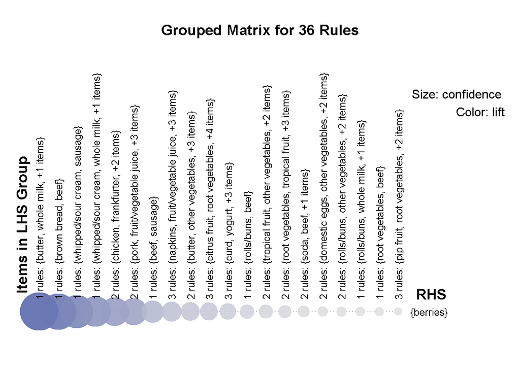

```r
plot(beef_rules, method = "grouped", measure = "confidence", control = list(col = sequential_hcl(100)))
```

The visualization based on the grouped matrix shows the different rules related to the purchase of berries, it can be observed that despite being a product that could go unnoticed; By placing this product as a consequence on the right, there are several products that link it with different types of consumer trends, such as dessert preparation, appetizers, part of the preparation of sauce to combine with main dishes such as meats, sausages and even as part of the list of products of people who lead a healthy lifestyle.

** Graphics-based visualizations **

[output not shown]

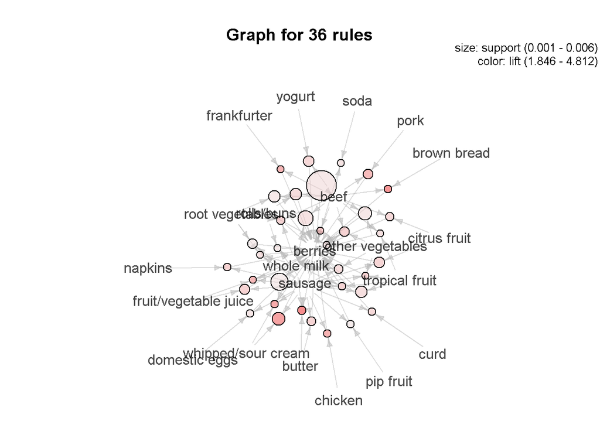

```r
plot(beef_rules, method = "graph", control = list(type = "items"))
```

In the graph above, you can see different types of products joined by different segments of arrows, whose consequence is the purchase of berries. The bubble graph shows the circumferences of beef, sausages and vegetables, which indicates that they are bought in greater proportion with respect to the other products.

** Display based on parallel coordinates **

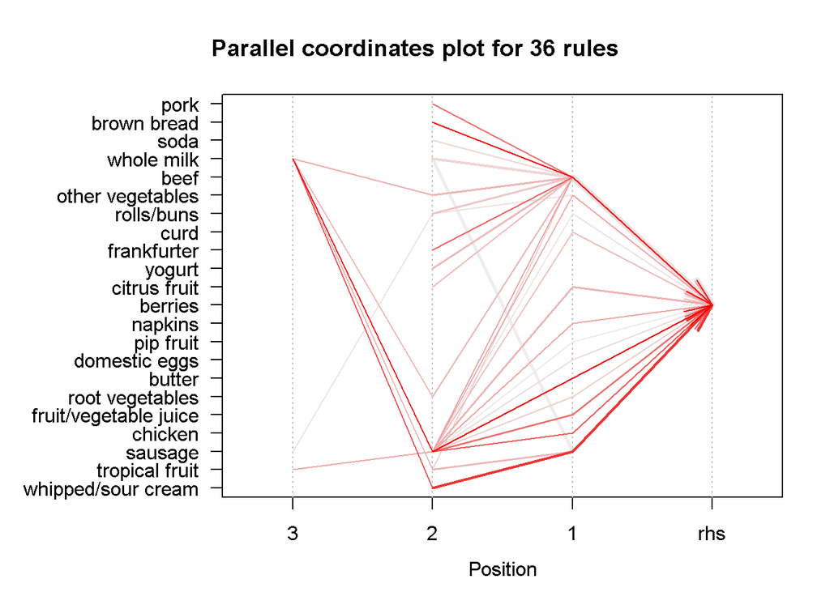

```r
plot(beef_rules, method = "paracoord", control = list(reorder = TRUE))
```